# Set Up

```python
# import modules and data
import pandas as pd
import numpy as np
import matplotlib.pyplot as plt
import seaborn as sns
import warnings
warnings.filterwarnings('ignore')

%matplotlib inline

countrycodes = pd.read_excel('Country-Code.xlsx')
restaurants = pd.read_excel('data.xlsx')

# merge datasets
df = pd.merge(countrycodes, restaurants, on='Country Code')
```

```python
df.head(2)
```

|  | Country Code | Country | Restaurant ID | Restaurant Name | City | Address | Locality | Locality Verbose | Longitude | Latitude | Cuisines | Average Cost for two | Currency | Has Table booking | Has Online delivery | Price range | Aggregate rating | Rating color | Rating text | Votes |
| --- | --- | --- | --- | --- | --- | --- | --- | --- | --- | --- | --- | --- | --- | --- | --- | --- | --- | --- | --- | --- |
| 0 | 1 | India | 2701 | Orient Express - Taj Palace Hotel | New Delhi | Taj Palace Hotel, Diplomatic Enclave, Chanakya... | The Taj Palace Hotel, Chanakyapuri | The Taj Palace Hotel, Chanakyapuri, New Delhi | 77.170087 | 28.595008 | European | 8000 | Indian Rupees(Rs.) | Yes | No | 4 | 4.0 | Green | Very Good | 145 |
| 1 | 1 | India | 309548 | Tian - Asian Cuisine Studio - ITC Maurya | New Delhi | ITC Maurya, Diplomatic Enclave, Chanakyapuri, ... | ITC Maurya, Chanakyapuri | ITC Maurya, Chanakyapuri, New Delhi | 77.173455 | 28.597351 | Asian, Japanese, Korean, Thai, Chinese | 7000 | Indian Rupees(Rs.) | No | No | 4 | 4.1 | Green | Very Good | 188 |

```python
# summary of dataframe
df.info()
```

```
<class 'pandas.core.frame.DataFrame'>
Int64Index: 9551 entries, 0 to 9550
Data columns (total 20 columns):
 #   Column                Non-Null Count  Dtype
---  ------                --------------  -----
 0   Country Code          9551 non-null   int64
 1   Country               9551 non-null   object
 2   Restaurant ID         9551 non-null   int64
 3   Restaurant Name       9550 non-null   object
 4   City                  9551 non-null   object
 5   Address               9551 non-null   object
 6   Locality              9551 non-null   object
 7   Locality Verbose      9551 non-null   object
 8   Longitude             9551 non-null   float64
 9   Latitude              9551 non-null   float64
 10  Cuisines              9542 non-null   object
 11  Average Cost for two  9551 non-null   int64
 12  Currency              9551 non-null   object
 13  Has Table booking     9551 non-null   object
 14  Has Online delivery   9551 non-null   object
 15  Price range           9551 non-null   int64
 16  Aggregate rating      9551 non-null   float64
 17  Rating color          9551 non-null   object
 18  Rating text           9551 non-null   object
 19  Votes                 9551 non-null   int64
dtypes: float64(3), int64(5), object(12)
memory usage: 1.5+ MB
```

- the data has 20 columns and 9551 rows including headers
- cuisines appear to have an extra row
- datatypes appear correct

# Data Wrangling

```python
# format columns to lower case
df.columns = df.columns.str.lower()

# remove spacing in columns
df.columns = df.columns.str.replace(' ', '')
```

```python
df.columns
```

```
Index(['countrycode', 'country', 'restaurantid', 'restaurantname', 'city',
       'address', 'locality', 'localityverbose', 'longitude', 'latitude',
       'cuisines', 'averagecostfortwo', 'currency', 'hastablebooking',
       'hasonlinedelivery', 'pricerange', 'aggregaterating', 'ratingcolor',
       'ratingtext', 'votes'],
      dtype='object')
```

```python
# format to concise column names
df = df.rename(columns={'averagecostfortwo':'averagecost', 'hastablebooking':'tablebooking', 'hasonlinedelivery':'onlinedelivery', 'aggregaterating':'rating'})
```

```python
# convert datatype for feature engineering
df.countrycode = df.countrycode.apply(str)
```

```python
# check for duplicates
df.duplicated().any()
```

```
False
```

```python
# % of missing values to assess most suitable treatment
round(df.isnull().sum().sort_values(ascending=False)/len(df)*100,2)
```

```
cuisines           0.09
restaurantname     0.01
averagecost        0.00
ratingtext         0.00
ratingcolor        0.00
rating             0.00
pricerange         0.00
onlinedelivery     0.00
tablebooking       0.00
currency           0.00
countrycode        0.00
country            0.00
latitude           0.00
longitude          0.00
localityverbose    0.00
locality           0.00
address            0.00
city               0.00
restaurantid       0.00
votes              0.00
dtype: float64
```

```python
# Arbitrary Imputation of missing values
df.restaurantname.replace([np.nan], 'N/A - Missing Value', inplace=True)
```

```python
# fill cuisine missing values with mode
df.fillna(value={'cuisines':df['cuisines'].mode()[0]}, inplace=True)
```

```python
# final missing value check
df.isnull().sum()
```

```
countrycode        0
country            0
restaurantid       0
restaurantname     0
city               0
address            0
locality           0
localityverbose    0
longitude          0
latitude           0
cuisines           0
averagecost        0
currency           0
tablebooking       0
onlinedelivery     0
pricerange         0
rating             0
ratingcolor        0
ratingtext         0
votes              0
dtype: int64
```

```python
# correct country names
df.city.replace({'BrasÌ_lia':'Brasil Lia', 'SÌ£o Paulo':'Sao Paulo', '€¡stanbul':'Istanbul'}, inplace=True)
```

```python
# drop irrelevant columns
df.drop(['address', 'localityverbose'], axis=1, inplace=True)

# reset df
df.reset_index(drop=True, inplace=True)
```

# Exploratory Data Analysis

```python
# statistics of df
df.describe(include='all')
```

|  | countrycode | country | restaurantid | restaurantname | city | locality | longitude | latitude | cuisines | averagecost | currency | tablebooking | onlinedelivery | pricerange | rating | ratingcolor | ratingtext | votes |
| --- | --- | --- | --- | --- | --- | --- | --- | --- | --- | --- | --- | --- | --- | --- | --- | --- | --- | --- |
| count | 9551 | 9551 | 9.551000e+03 | 9551 | 9551 | 9551 | 9551.000000 | 9551.000000 | 9551 | 9551.000000 | 9551 | 9551 | 9551 | 9551.000000 | 9551.000000 | 9551 | 9551 | 9551.000000 |
| unique | 15 | 15 | NaN | 7446 | 141 | 1208 | NaN | NaN | 1825 | NaN | 12 | 2 | 2 | NaN | NaN | 6 | 6 | NaN |
| top | 1 | India | NaN | Cafe Coffee Day | New Delhi | Connaught Place | NaN | NaN | North Indian | NaN | Indian Rupees(Rs.) | No | No | NaN | NaN | Orange | Average | NaN |
| freq | 8652 | 8652 | NaN | 83 | 5473 | 122 | NaN | NaN | 945 | NaN | 8652 | 8393 | 7100 | NaN | NaN | 3737 | 3737 | NaN |
| mean | NaN | NaN | 9.051128e+06 | NaN | NaN | NaN | 64.126574 | 25.854381 | NaN | 1199.210763 | NaN | NaN | NaN | 1.804837 | 2.666370 | NaN | NaN | 156.909748 |
| std | NaN | NaN | 8.791521e+06 | NaN | NaN | NaN | 41.467058 | 11.007935 | NaN | 16121.183073 | NaN | NaN | NaN | 0.905609 | 1.516378 | NaN | NaN | 430.169145 |
| min | NaN | NaN | 5.300000e+01 | NaN | NaN | NaN | -157.948486 | -41.330428 | NaN | 0.000000 | NaN | NaN | NaN | 1.000000 | 0.000000 | NaN | NaN | 0.000000 |
| 25% | NaN | NaN | 3.019625e+05 | NaN | NaN | NaN | 77.081343 | 28.478713 | NaN | 250.000000 | NaN | NaN | NaN | 1.000000 | 2.500000 | NaN | NaN | 5.000000 |
| 50% | NaN | NaN | 6.004089e+06 | NaN | NaN | NaN | 77.191964 | 28.570469 | NaN | 400.000000 | NaN | NaN | NaN | 2.000000 | 3.200000 | NaN | NaN | 31.000000 |
| 75% | NaN | NaN | 1.835229e+07 | NaN | NaN | NaN | 77.282006 | 28.642758 | NaN | 700.000000 | NaN | NaN | NaN | 2.000000 | 3.700000 | NaN | NaN | 131.000000 |
| max | NaN | NaN | 1.850065e+07 | NaN | NaN | NaN | 174.832089 | 55.976980 | NaN | 800000.000000 | NaN | NaN | NaN | 4.000000 | 4.900000 | NaN | NaN | 10934.000000 |

```python
# no. of unique restaurantid
df.restaurantid.nunique()
```

```
9551
```

```python
# no. of unique restaurantname
df.restaurantname.nunique()
```

```
7446
```

## Geographical Distribution

### Total Resturants by Countries

```python
# restaurant count and % by country
geodf = df.groupby(['country'], as_index=False)['restaurantid'].count()
geodf.rename(columns={'restaurantid':'totalrestaurants'}, inplace=True)
geodf['percent'] = (geodf.totalrestaurants/geodf.totalrestaurants.sum()*100).round(1)

geodf.sort_values(by='percent', ascending=False)
```

|  | country | totalrestaurants | percent |
| --- | --- | --- | --- |
| 3 | India | 8652 | 90.6 |
| 14 | United States | 434 | 4.5 |
| 13 | United Kingdom | 80 | 0.8 |
| 1 | Brazil | 60 | 0.6 |
| 9 | South Africa | 60 | 0.6 |
| 12 | UAE | 60 | 0.6 |
| 5 | New Zealand | 40 | 0.4 |
| 11 | Turkey | 34 | 0.4 |
| 0 | Australia | 24 | 0.3 |
| 4 | Indonesia | 21 | 0.2 |
| 6 | Phillipines | 22 | 0.2 |
| 7 | Qatar | 20 | 0.2 |
| 8 | Singapore | 20 | 0.2 |
| 10 | Sri Lanka | 20 | 0.2 |
| 2 | Canada | 4 | 0.0 |

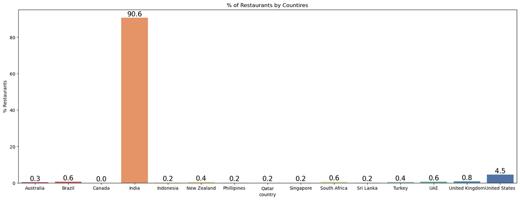

```python
# Barplot of resturants vs countires

plt.figure(figsize = (20,7))
plot_annotate = sns.barplot(geodf, x='country', y='percent', palette='Spectral')

# annotate %
for bar in plot_annotate.patches:
    plot_annotate.annotate(format(bar.get_height(), '.1f'),
                 (bar.get_x() + bar.get_width()/2,
                 bar.get_height()), ha='center', va='center', size=15,
                 xytext=(0,8), textcoords='offset points')

plt.ylabel('% Restaurants')
plt.title('% of Restaurants by Countires')
plt.show()
```

### Top 10 Cities with most Restaurants

```python
city_df = df.groupby(['city'], as_index=False)['restaurantid'].count()
city_df.rename(columns={'restaurantid':'totalrestaurants'}, inplace=True)
city_df['percent'] = (city_df.totalrestaurants/sum(city_df.totalrestaurants)*100).round(1)
```

```python
top_cities = city_df.nlargest(10, ['totalrestaurants'])
top_cities
```

|  | city | totalrestaurants | percent |
| --- | --- | --- | --- |
| 89 | New Delhi | 5473 | 57.3 |
| 50 | Gurgaon | 1118 | 11.7 |
| 90 | Noida | 1080 | 11.3 |
| 43 | Faridabad | 251 | 2.6 |
| 48 | Ghaziabad | 25 | 0.3 |
| 2 | Ahmedabad | 21 | 0.2 |
| 5 | Amritsar | 21 | 0.2 |
| 17 | Bhubaneshwar | 21 | 0.2 |
| 51 | Guwahati | 21 | 0.2 |
| 70 | Lucknow | 21 | 0.2 |

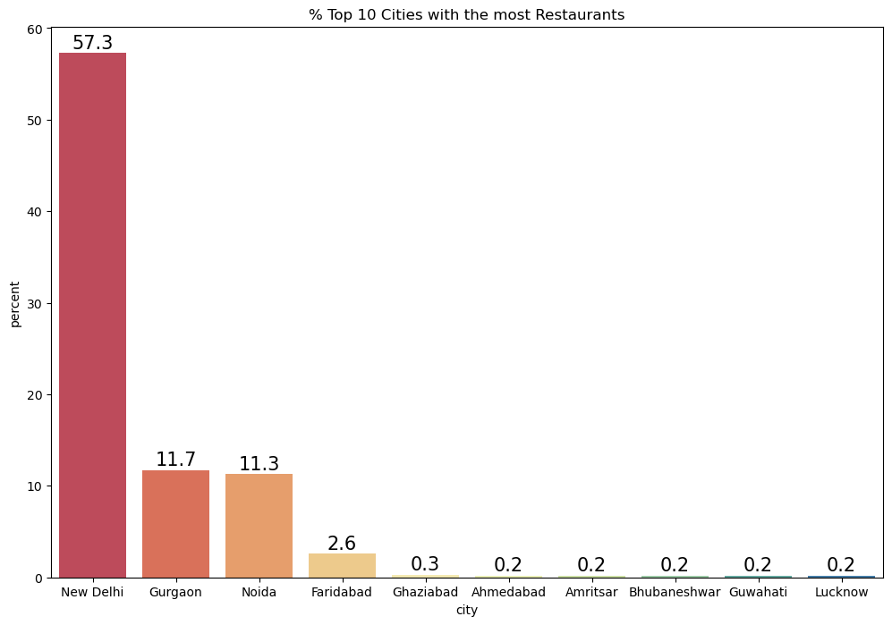

```python
plt.figure(figsize=(12,8))
graph = sns.barplot(top_cities, x='city', y='percent', palette='Spectral')

# annotate graph
for bar in graph.patches:
    graph.annotate(format(bar.get_height(), '.1f'),
                   (bar.get_x() + bar.get_width()/2,
                    bar.get_height()), ha='center',
                   va='center', size=15, xytext=(0,8), textcoords='offset points'
                  )

plt.title('% Top 10 Cities with the most Restaurants')
plt.show()
```

### Ratings Distribution

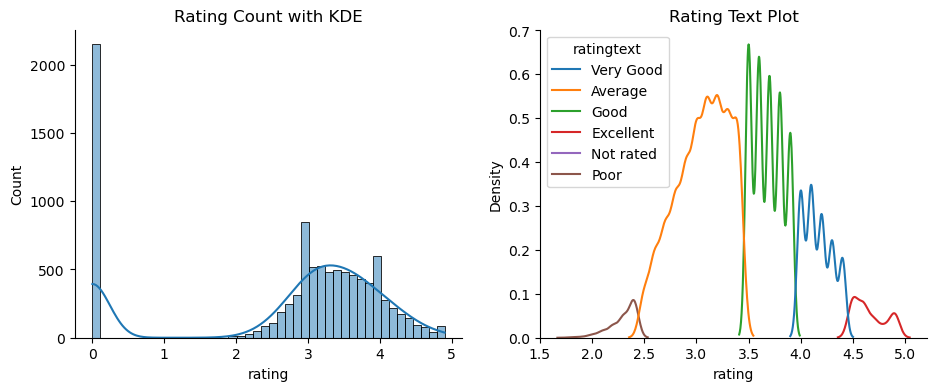

```python
fig, axes=plt.subplots(1,2,figsize=(11,4), sharey=False)
sns.histplot(df, x='rating', kde=True, palette='Spectral', ax=axes[0])
axes[0].set_title('Rating Count with KDE')
sns.kdeplot(df, x='rating', hue='ratingtext', ax=axes[1])
axes[1].set_title('Rating Text Plot')

sns.despine(right=True, top=True)
```

- Over 2000 ratings are 0, indicating no rating recorded
- Most valid ratings are between values 3 and 4
- 'Avearge' and 'Good' dominate 'textrating'
- 'Poor' and 'Excellent' appear almost equal in volume

### Largest Franchises

```python
franchise = df.groupby(['country', 'restaurantname'], as_index=False)['restaurantid'].count()
franchise.rename(columns={'restaurantid':'restcount'}, inplace=True)
```

```python
# select top 10 largest franchises
top_franchise = franchise.nlargest(10, ['restcount'])
top_franchise
```

|  | country | restaurantname | restcount |
| --- | --- | --- | --- |
| 1061 | India | Cafe Coffee Day | 83 |
| 1975 | India | Domino's Pizza | 79 |
| 5523 | India | Subway | 63 |
| 2486 | India | Green Chick Chop | 51 |
| 3689 | India | McDonald's | 48 |
| 3169 | India | Keventers | 34 |
| 2408 | India | Giani | 29 |
| 4480 | India | Pizza Hut | 29 |
| 705 | India | Baskin Robbins | 28 |
| 690 | India | Barbeque Nation | 25 |

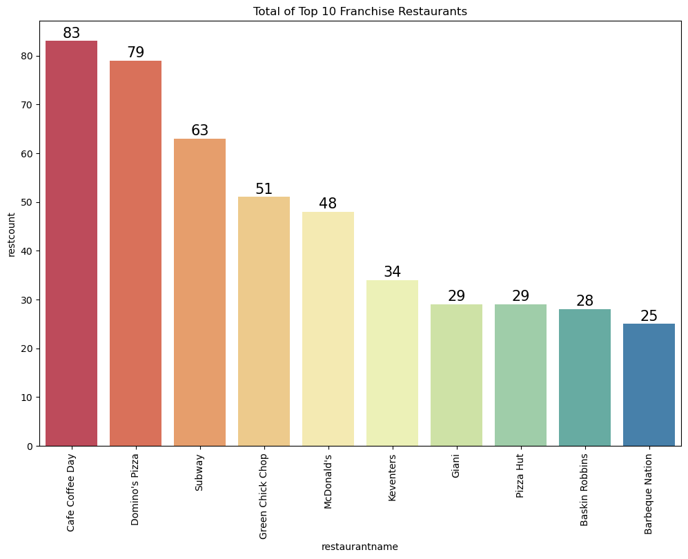

```python
# barplot
plt.figure(figsize=(12, 8))

plots = sns.barplot(top_franchise, x='restaurantname', y='restcount', palette='Spectral')

# annotate bars
for bar in plots.patches:
    plots.annotate(format(bar.get_height(), '.0f'),
                   (bar.get_x() + bar.get_width() / 2,
                    bar.get_height()), ha='center', va='center',
                   size=15, xytext=(0, 8),
                   textcoords='offset points')

plt.xticks(rotation=90)
plt.title('Total of Top 10 Franchise Restaurants')
plt.show()
```

### Ratio of Table Booking Service

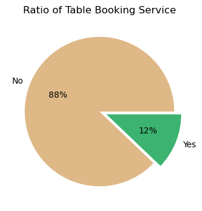

```python
plt.figure(figsize=(4,4))
plt.pie(x=df['tablebooking'].value_counts(), labels=df['tablebooking'].value_counts().index,
       autopct='%.0f%%', explode=[0,0.1], colors=['burlywood', 'mediumseagreen'])
plt.title('Ratio of Table Booking Service')
plt.show()
```

- The ratio of table booking services is approximately 9:1
- Majority of resturants do not offer booking services

### % of Online Delivery Service

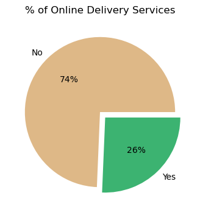

```python
plt.figure(figsize=(4,4))
plt.pie(x=df['onlinedelivery'].value_counts(), labels=df['onlinedelivery'].value_counts().index ,
       autopct='%.0f%%', explode=[0,0.1], colors=['burlywood', 'mediumseagreen'])
plt.title('% of Online Delivery Services')
plt.show()
```

- Almost 75% of resturants don't offer online delivery services
- Most restaurants do not provide delivery services

### Votes vs Online Delivery

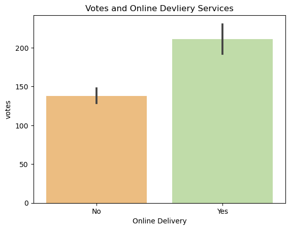

```python
sns.barplot(df, x='onlinedelivery', y='votes', ci=95, palette='Spectral')
plt.title('Votes and Online Devliery Services')
plt.xlabel('Online Delivery')
plt.show()
```

- Higher volume of votes are seen for 'Yes' delivery services

## Top Cuisines

```python
# extract cuisines from string
l = []
for i in df.cuisines.str.split(', '):
    l.extend(i)
food = pd.Series([i.strip() for i in l])

# list of food value counts
food.value_counts()
```

```
North Indian      3969
Chinese           2735
Fast Food         1986
Mughlai            995
Italian            764
                  ...
Peranakan            1
BÌ_rek               1
DÌ_ner               1
Fish and Chips       1
Bubble Tea           1
Length: 145, dtype: int64
```

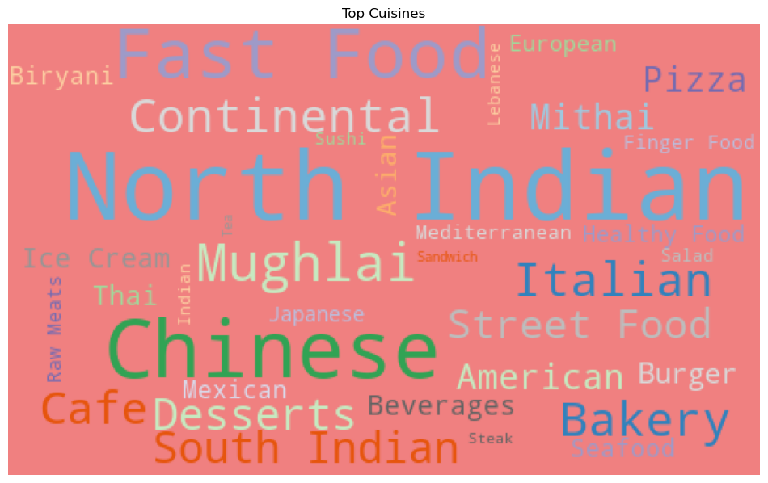

```python
from wordcloud import WordCloud, STOPWORDS
stopwords = set(STOPWORDS)

wordcloud = (WordCloud(width=500, height=300, random_state=1, background_color='lightcoral',
                       colormap='tab20c', stopwords=stopwords).generate_from_frequencies(food.value_counts().head(35)))
fig = plt.figure(1,figsize=(12, 10))
plt.imshow(wordcloud)
plt.title('Top Cuisines')
plt.axis('off')
plt.show()
```

### Top 10 Cuisines served in Restaurants

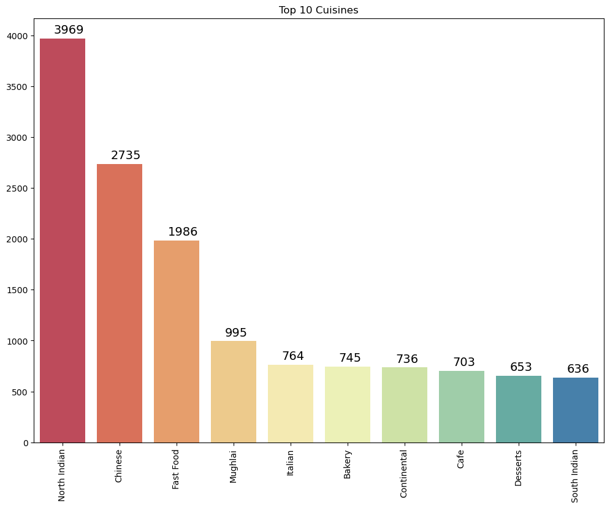

```python
plt.figure(figsize=(12,9))
sns.barplot(x = food.value_counts()[:10].index, y = food.value_counts()[:10], palette='Spectral' )

for i in range(10):
    plt.annotate(food.value_counts()[i], xy = (i-0.15,food.value_counts()[i]+50),
                 fontsize = 14)

plt.xticks(rotation=90)
plt.title('Top 10 Cuisines')
plt.show()
```

## Total Cuisines served by Restaurant

```python
# create new column with cuisines count
df['cui_count'] = df.cuisines.apply(lambda x: len(x.split(', ')))
```

### Maximum Cuisines

```python
# select top 5 largest counts
maxfood = df.nlargest(5, ['cui_count'])
maxfood[['restaurantname', 'city', 'rating', 'averagecost', 'currency', 'cui_count']]
```

|  | restaurantname | city | rating | averagecost | currency | cui_count |
| --- | --- | --- | --- | --- | --- | --- |
| 939 | R' ADDA | Mumbai | 4.0 | 1200 | Indian Rupees(Rs.) | 8 |
| 1200 | Mumbai Vibe | Mumbai | 3.8 | 1000 | Indian Rupees(Rs.) | 8 |
| 2716 | Bikanervala | Gurgaon | 3.4 | 600 | Indian Rupees(Rs.) | 8 |
| 3204 | Indian Summer Cafe | Patna | 3.4 | 600 | Indian Rupees(Rs.) | 8 |
| 3290 | Bikanervala | New Delhi | 3.5 | 550 | Indian Rupees(Rs.) | 8 |

- The maximum count of cuisines served in a resturant is 8

### Minimum Cuisines

```python
# select top smallest counts
minfood = df.nsmallest(5, ['cui_count'])
minfood[['restaurantname', 'city', 'rating', 'averagecost', 'currency', 'cui_count']]
```

|  | restaurantname | city | rating | averagecost | currency | cui_count |
| --- | --- | --- | --- | --- | --- | --- |
| 0 | Orient Express - Taj Palace Hotel | New Delhi | 4.0 | 8000 | Indian Rupees(Rs.) | 1 |
| 2 | Bukhara - ITC Maurya | New Delhi | 4.4 | 6500 | Indian Rupees(Rs.) | 1 |
| 8 | House of Ming - The Taj Mahal Hotel | New Delhi | 4.0 | 5500 | Indian Rupees(Rs.) | 1 |
| 10 | Wildfire - Crowne Plaza | Gurgaon | 3.7 | 5000 | Indian Rupees(Rs.) | 1 |
| 12 | Masala Library | New Delhi | 4.9 | 5000 | Indian Rupees(Rs.) | 1 |

- The minimum amount of cuisines served is 1

### Frequency of Cuisine Counts

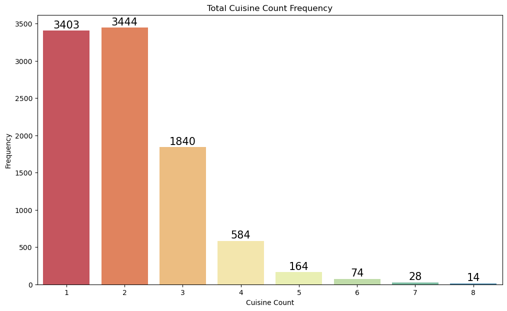

```python
plt.figure(figsize=(12,7))
plotting = sns.countplot(df, x='cui_count', palette='Spectral')
for bar in plotting.patches:
    plotting.annotate(format(bar.get_height(), '.0f'),
                   (bar.get_x() + bar.get_width() / 2,
                    bar.get_height()), ha='center', va='center',
                   size=15, xytext=(0, 8),
                   textcoords='offset points')

plt.title('Total Cuisine Count Frequency')
plt.xlabel('Cuisine Count')
plt.ylabel('Frequency')
plt.show()
```

## Relationship of Ratings vs No. of Cuisines

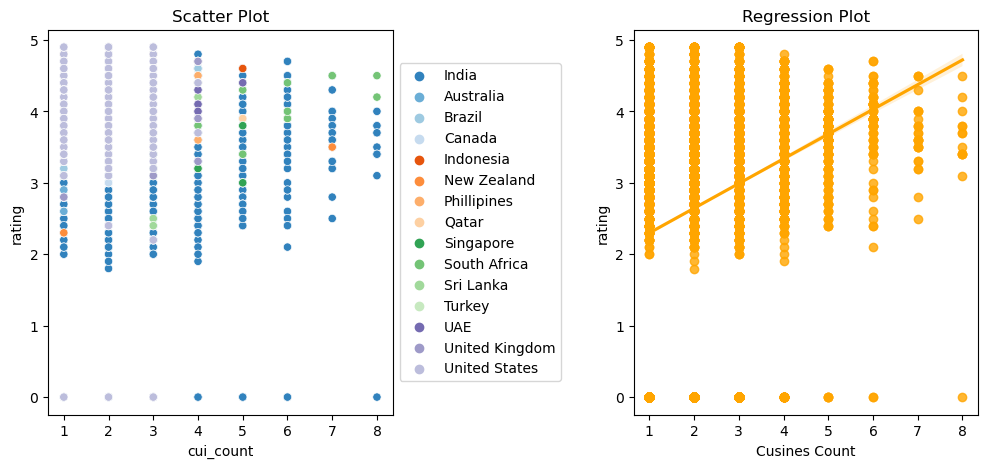

```python
fig, axes = plt.subplots(1,2,figsize=(12,5))
plt.subplots_adjust(hspace = 0.5 , wspace = 0.7)
sns.scatterplot(df, x= 'cui_count', y= 'rating', hue='country',
                 ax = axes[0], palette = 'tab20c')
plt.xlabel('Cuisines Count')
axes[0].legend(loc='center left', bbox_to_anchor=(1, 0.5))
axes[0].set_title('Scatter Plot')


sns.regplot(df, x= 'cui_count', y= 'rating', color='orange', ax = axes[1], ci=80)
axes[1].set_title('Regression Plot')
plt.xlabel('Cusines Count')
plt.show()
```

## Average Cost by Country

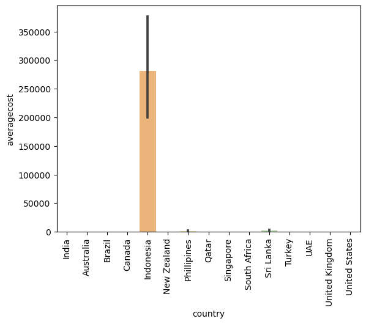

```python
sns.barplot(x='country',y='averagecost',palette="Spectral",data=df)
plt.xticks(rotation='90')
plt.show()
```

- it's difficult to compare the 'averagecost' amongst countries as each country's currency value and exchange rate is different
- Indonesia is appearing to have the highest 'averagecost' due to it's IDR currency which has many thousands but may not be equal in worth with other currencies

# Relationships of Ratings

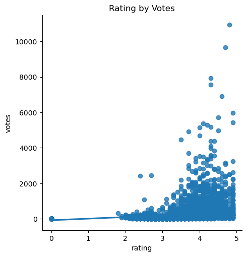

```python
sns.lmplot(df, x='rating', y='votes')
plt.title('Rating by Votes')
plt.show()
```

- Higher ratings are received with higher volume of votes

### Correlations of Numerical Attributes

```python
# enumerate 'onlineodelivery' and 'tablebooking'
dummy_df = df.copy()
dummy_df = pd.get_dummies(dummy_df, columns=['onlinedelivery', 'tablebooking'], drop_first=True)
dummy_df[['onlinedelivery_Yes', 'tablebooking_Yes']].head()
```

|  | onlinedelivery_Yes | tablebooking_Yes |
| --- | --- | --- |
| 0 | 0 | 1 |
| 1 | 0 | 0 |
| 2 | 0 | 0 |
| 3 | 0 | 1 |
| 4 | 0 | 1 |

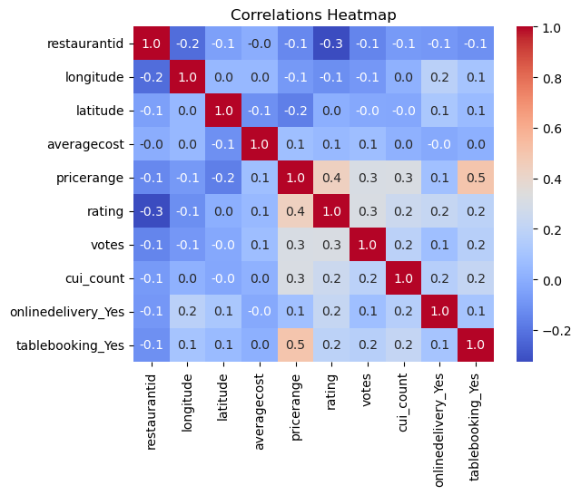

```python
sns.heatmap(dummy_df.corr(), annot=True, fmt='.1f', cmap='coolwarm')
plt.title('Correlations Heatmap')
plt.show()
```

- 'rating' and 'votes' have a correlation of 0.3, indicating the number of 'votes' affect the 'rating'
- 'pricerange' and 'rating' have a correlation of 0.4, suggesting a higher rating is recevied for more 'pricerange'
- 'pricerange' and 'tablebooking_yes' have a correlation of 0.5, implying resturants with more 'pricerange' has the 'tablebooking' service

### Pairplot of Ratings vs other Attributes

```python
to_pairplot = dummy_df[['rating', 'averagecost', 'pricerange', 'votes', 'cui_count', 'country', 'onlinedelivery_Yes', 'tablebooking_Yes']]
```

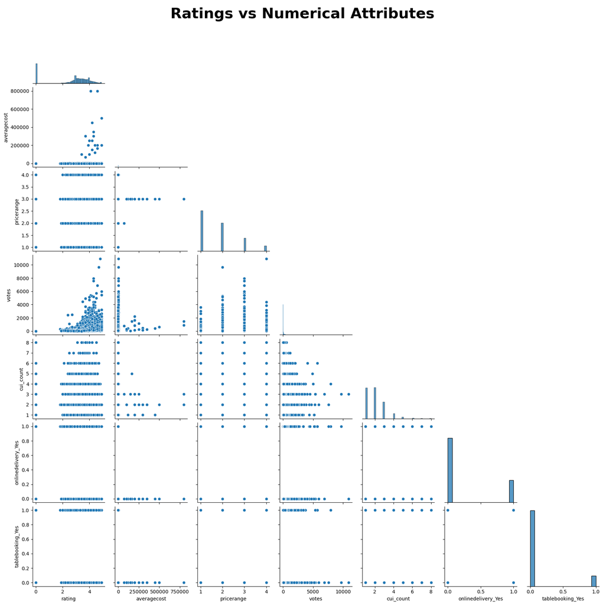

```python
plt.style.use('fast')
plt.figure(figsize=(12,6))
sns.pairplot(to_pairplot, palette='Spectral', corner=True)
plt.suptitle('Ratings vs Numerical Attributes', fontsize='30', fontweight='heavy')
plt.show()
```

# Conclusion

- From our EDA, the data presents that 'rating' is mostly correlated to 'pricerange', at 0.4. The higher the 'pricerange', the higher the 'rating' score.
- 'rating' and 'votes' are also correlated by 0.3 which suggests more 'votes' contributes to higher 'rating' scores.
- There appears to be more 'rating' scores for restuarants that have between 1-4 'cuisines' than others
- The 'rating' is not clealrly affected by restaurants providing 'onlinedelivery' or 'tablebooking; services.

```python
df.to_excel('checkedcapstone1restaurants.xlsx')
```

### Tableau Dashboard

Tableau Dashboard: https://public.tableau.com/views/RestaurantRatings_16749023337480/RestaurantDash?:language=en-US&publish=yes&:display_count=n&:origin=viz_share_link